# MANOVA (ANOVA multivariada) com uma única variável independente no R (analisando dados em painel)

A MANOVA é uma extensão da ANOVA que permite o uso de mais de uma variável dependente (seria uma ANOVA multivariada). No entanto, nesse nosso exemplo, efetuaremos a análise com uma única variável independente para mais de uma variável dependente.

# 1 O que vamos executar?

- Verificar a normalidade dos dados (univariada x multivariada);
- Verificar a homogeneidade das matrizes covariâncias-variâncias entre os grupos (teste M de Box - equivalente ao teste de Levene);
- Verificar se há *outliers* multivariados;
- Verificar se há multicolinearidade;
- Verificar a linearidade entre os pares de observações;
- Fazer, interpretar e descrever a MANOVA.

# 2 Situação problema

O `Banco de Dados 6.csv` contém informações de 48 indivíduos divididos em três grupos: um grupo que não consumiu álcool, um grupo que consumiu duas canecas e um grupo que consumiu quatro canecas. Os indivíduos foram então submetidos a um teste de memória, e o banco traz o escore nesse teste e a latência para responder às questões. Verifique se há efeito do consumo de álcool sobre a memória e sobre a latência através de uma análise multivariada. Descreva os resultados de forma apropriada.

Analisaremos o consumo de álcool como variável independente, este que possui três categorias: não consumir álcool, consumir duas canecas e consumir quatro canecas - esse consumo poderia ser representado em nosso modelo como variáveis independentes e categóricas. E para variáveis dependentes, trabalharemos com duas: `Memória` e `Latencia`.

# 3 Efetuando a Análise

É necessário seguir alguns passos importantes.

## 3.1 Passo 1: Carregar os pacotes de dados

```r
if(!require(dplyr)) install.packages("dplyr")
library(dplyr)
if(!require(car)) install.packages("car")
library(car)
if(!require(rstatix)) install.packages("rstatix")
library(rstatix)
if(!require(emmeans)) install.packages("emmeans")
library(emmeans)
if(!require(ggplot2)) install.packages("ggplot2")
library(ggplot2)
if(!require(MVN)) install.packages("MVN")
library(MVN)
if(!require(GGally)) install.packages("GGally")
library(GGally)
```

## 3.2 Passo 2: Carregar o banco de dados

Detalhe importante: selecionar o diretório de trabalho via *Session/Set Working Directory/Choose Directory*.

```r
dados <- read.csv2('Banco de Dados 6.csv', stringsAsFactors = T,
                   fileEncoding = "latin1")
glimpse(dados)
```

```
## Rows: 48
## Columns: 4
## $ Genero   <fct> Masculino, Feminino, Feminino, Masculino, Masculino, Masculin~
## $ Alcool   <fct> 4 Canecas, 4 Canecas, 4 Canecas, 4 Canecas, 2 Canecas, 4 Cane~
## $ Memoria  <int> 20, 50, 55, 30, 85, 30, 30, 65, 70, 35, 80, 65, 40, 80, 75, 4~
## $ Latencia <dbl> 2.1, 5.2, 5.0, 3.8, 2.9, 3.0, 3.1, 4.2, 3.9, 2.9, 1.7, 4.0, 3~
```

```r
library(rmarkdown)
paged_table(dados)
```

| Genero | Alcool | Memoria | Latencia |
| --- | --- | --- | --- |
| Masculino | 4 Canecas | 20 | 2.1 |
| Feminino | 4 Canecas | 50 | 5.2 |
| Feminino | 4 Canecas | 55 | 5.0 |
| Masculino | 4 Canecas | 30 | 3.8 |
| Masculino | 2 Canecas | 85 | 2.9 |
| Masculino | 4 Canecas | 30 | 3.0 |
| Masculino | 4 Canecas | 30 | 3.1 |
| Feminino | 4 Canecas | 65 | 4.2 |
| Feminino | 2 Canecas | 70 | 3.9 |
| Masculino | 4 Canecas | 35 | 2.9 |

[output cut: 38 more lines]

## 3.3 Passo 3: Verificação da normalidade MULTIVARIADA - por grupo:

Verificamos que a MANOVA é uma ANOVA expandida para comportar mais variáveis dependentes. Então teremos alguns pressupostos que são muito parecidos com os da ANOVA, só que também estão expandidos, por exemplo, quando trabalhamos com a ANOVA, um dos pressupostos seria a normalidade por grupo (cada grupo tem que apresentar distribuição normal) e quando trabalhamos com a MANOVA, esse pressuposto valerá para todas as variáveis dependentes simultaneamente - isso seria a verificação da normalidade MULTIVARIADA. Verificaremos pelo *Shapiro-Test* e pelo teste de *Henze-Zirkler*.

### 3.3.1 Teste de *Shapiro-Wilk* (pacote `rstatix`):

```r
dados %>% select(2:4) %>% group_by(Alcool) %>%
  doo(~mshapiro_test(.))
```

```
## # A tibble: 3 x 3
##   Alcool    statistic p.value
##   <fct>         <dbl>   <dbl>
## 1 2 Canecas     0.980  0.967
## 2 4 Canecas     0.964  0.740
## 3 Nenhum        0.872  0.0294
```

```r
# selecionamos as colunas de 2 a 4, agrupados pela variável Alcool e usamos a função doo para aplicar todas as variáveis no teste.
```

Lembrando que os pressupostos do *Teste de Shapiro-Wilk* são:

- H<sub>0</sub>: Distribuição dos dados = normal → p > 0,05
- H<sub>1</sub>: Distribuição dos dados ≠ normal → p ≤ 0,05

Nesse caso, então, temos um problema quando para o grupo `Nenhum` temos que a hipótese nula é rejeitada, ou seja, os dados não possuem distribuição normal. No entanto, temos que o teste de *Shapiro* não é o melhor para análises multivariadas (mais de uma variável dependente), razão pela qual utilizamos o teste de *Henze-Zirkler*.

### 3.3.2 Teste de *Henze-Zirkler* (pacote `MVN`):

```r
mvn(data = dados[,2:4], subset = "Alcool", mvnTest = "hz")
```

```
## $multivariateNormality
## $multivariateNormality$`2 Canecas`
##            Test        HZ  p value MVN
## 1 Henze-Zirkler 0.4093407 0.373914 YES
##
## $multivariateNormality$`4 Canecas`
##            Test        HZ   p value MVN
## 1 Henze-Zirkler 0.3503921 0.5228568 YES
##
## $multivariateNormality$Nenhum
##            Test        HZ    p value MVN
## 1 Henze-Zirkler 0.6121755 0.09645177 YES
##
##
## $univariateNormality
## $univariateNormality$`2 Canecas`
##               Test  Variable Statistic   p value Normality
## 1 Anderson-Darling  Memoria     0.4983    0.1800    YES
## 2 Anderson-Darling Latencia     0.3577    0.4087    YES
##
## $univariateNormality$`4 Canecas`
##               Test  Variable Statistic   p value Normality
## 1 Anderson-Darling  Memoria     0.3884    0.3434    YES
## 2 Anderson-Darling Latencia     0.2255    0.7828    YES
##
## $univariateNormality$Nenhum
##               Test  Variable Statistic   p value Normality
## 1 Anderson-Darling  Memoria     0.3507    0.4249    YES
## 2 Anderson-Darling Latencia     0.7875    0.0321    NO
##
##
## $Descriptives
## $Descriptives$`2 Canecas`
##           n     Mean   Std.Dev Median  Min Max  25th   75th       Skew
## Memoria  16 64.68750 9.9110628   65.0 45.0  85 60.00 70.000 0.08068595
## Latencia 16  2.58125 0.7892771    2.5  1.4   4  2.05  2.975 0.43939645
##            Kurtosis
## Memoria  -0.2303871
## Latencia -1.0587875
##
## $Descriptives$`4 Canecas`
##           n     Mean    Std.Dev Median  Min  Max  25th  75th      Skew
## Memoria  16 46.56250 14.3432621  50.00 20.0 70.0 33.75 55.00 -0.215011
## Latencia 16  3.35625  0.9959711   3.35  1.8  5.2  2.75  3.85  0.172151
##            Kurtosis
## Memoria  -1.2076401
## Latencia -0.9812383
##
## $Descriptives$Nenhum
##           n  Mean   Std.Dev Median  Min  Max   25th   75th      Skew   Kurtosis
## Memoria  16 63.75 8.4656167  62.50 50.0 80.0 58.750 70.000 0.2897322 -1.0658358
## Latencia 16  1.95 0.5403702   1.75  1.4  3.1  1.575  2.225 0.8876619 -0.5155106
```

```r
# De forma análoga selecionamos os dados de 2 a 4, dividido por grupo "Alcool".
```

Os pressupostos do *Teste de Henze-Zirkler* são os mesmos, e segue a premissa de normalidade:

- H<sub>0</sub>: Distribuição dos dados = normal → p > 0,05
- H<sub>1</sub>: Distribuição dos dados ≠ normal → p ≤ 0,05

### 3.3.3 Verificação da normalidade UNIVARIADA - por grupo:

```r
dados %>% group_by(Alcool) %>%
  shapiro_test(Latencia, Memoria)
```

```
## # A tibble: 6 x 4
##   Alcool    variable statistic      p
##   <fct>     <chr>        <dbl>  <dbl>
## 1 2 Canecas Latencia     0.942 0.378
## 2 2 Canecas Memoria      0.945 0.413
## 3 4 Canecas Latencia     0.963 0.708
## 4 4 Canecas Memoria      0.952 0.522
## 5 Nenhum    Latencia     0.865 0.0226
## 6 Nenhum    Memoria      0.955 0.572
```

Aportamos a análise univariada com o *Teste de Shapiro* como um exemplo, pois caso o teste para análise multivariada tivesse aceito a hipótese nula para os três grupos, poderíamos também efetuar análise univariada com o mesmo método.

## 3.4 Passo 4: Verificação da presença de *outliers* MULTIVARIADOS

### 3.4.1 Pela distância de *Mahalanobis* (*outlier* = `p < 0,001`)

A função `mahalanobis_distance` já aporta a existência de outliers considerando a distância de 0.001. Nesse caso, não tem *outliers* conforme podemos ver na sequência:

```r
outliersm <- dados %>% dplyr::select(2:4) %>% group_by(Alcool) %>%
  doo(~mahalanobis_distance(.)) %>%
  filter(is.outlier == TRUE)
head(outliersm, 10)
```

```
## # A tibble: 0 x 5
## # ... with 5 variables: Alcool <fct>, Memoria <int>, Latencia <dbl>,
## #   mahal.dist <dbl>, is.outlier <lgl>
```

### 3.4.2 Verificação da presença de *outliers* UNIVARIADOS - por grupo:

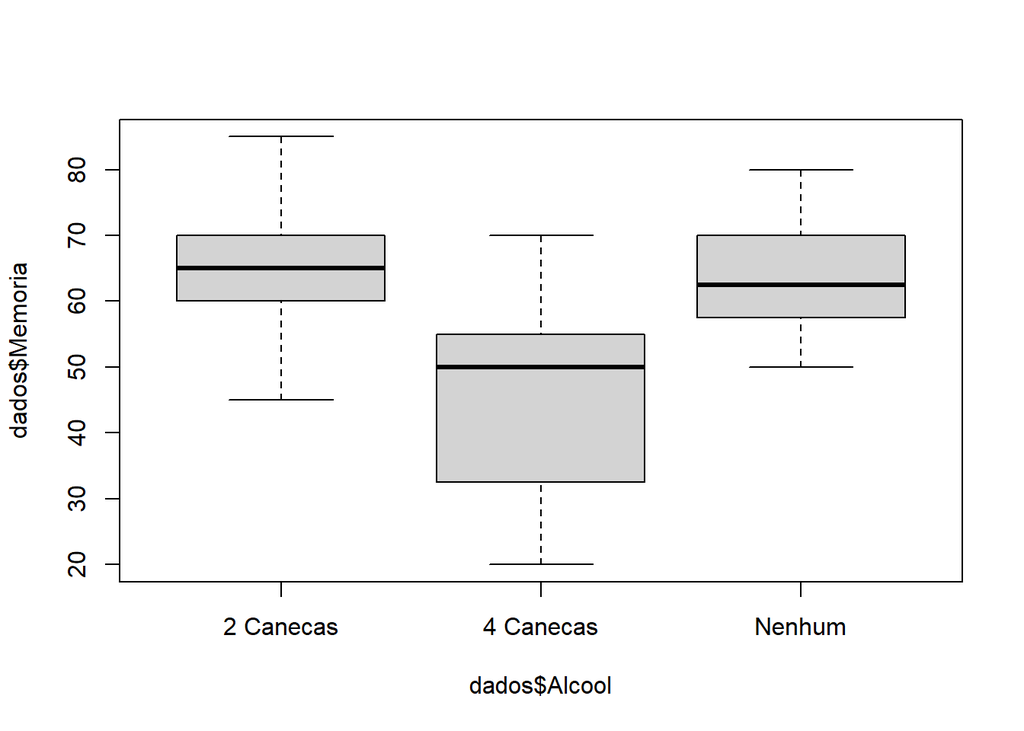

```r
boxplot(dados$Memoria ~ dados$Alcool)
```

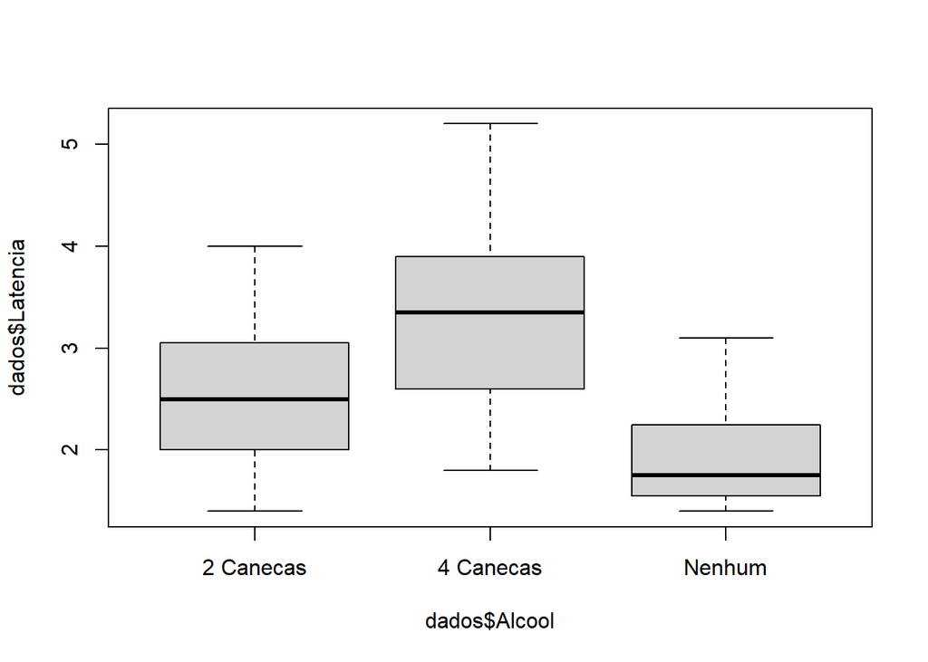

```r
boxplot(dados$Latencia ~ dados$Alcool)
```

```r
dados %>% group_by(Alcool) %>%
  identify_outliers(Memoria)
```

```
## [1] Alcool     Genero     Memoria    Latencia   is.outlier is.extreme
## <0 linhas> (ou row.names de comprimento 0)
```

```r
dados %>% group_by(Alcool) %>%
  identify_outliers(Latencia)
```

```
## [1] Alcool     Genero     Memoria    Latencia   is.outlier is.extreme
## <0 linhas> (ou row.names de comprimento 0)
```

Assim, verificamos que os dados atendem aos pressupostos de normalidade e de ausência de *outliers*.

## 3.5 Passo 5: Verificação da homogeneidade das matrizes de covariâncias e variâncias

Outra coisa importante a se preocupar para efetuar a análise da MANOVA, é com a homogeneidade das variâncias. Quando a gente pensa na ANOVA, a gente verifica se a variável dependente tem variâncias homogêneas em todos os grupos da variável independente - e fazemos isso efetuando o *Teste de Levene* (pelo pacote `car`).

Mas quando lidamos com ANOVA multivariada, já não dá para aplicarmos o *Teste de Levene*, porque ele funciona para quando a gente tem uma única variável dependente. Nesse caso, para a MANOVA, utilizamos o teste de *M de box*, que verifica a homogeneidade das matrizes de covariâncias e variâncias. O teste de *M de box* é muito sensível, então a recomendação é que atuemos com Alfa = 0.001 (estatisticamente significativo valores acima de 0,1%) e, se esse critério for rompido, tendo n iguais por grupo, corrigimos para *Pillai* e *Hotelling*. Caso os n sejam diferentes, uma opção é usar uma MANOVA robusta, com Alfa: 0,001.

Pressupostos do teste de *M de box*:

- H<sub>0</sub>: as matrizes de variância-covariância são homogêneas → p > 0.001
- H<sub>1</sub>: as matrizes de variância-covariância **não** são homogêneas → p ≤ 0.001

Nesse caso, como p > 0.001, não rejeitamos a hipótese nula e entendemos que os dados seguem também o pressuposto de homogeneidade das variâncias.

```r
box_m(dados[,3:4], dados$Alcool)
```

```
## # A tibble: 1 x 4
##   statistic p.value parameter method
##       <dbl>   <dbl>     <dbl> <chr>
## 1      9.24   0.161         6 Box's M-test for Homogeneity of Covariance Matric~
```

### 3.5.1 Verificação da homogeneidade de variâncias - teste de *Levene* (pacote `car`).

Como depois da MANOVA, a gente faz a ANOVA e, para isso, também precisamos seguir parâmetros de homogeneidade de variâncias. Efetuamos agora a análise por meio do *Levene-test*, pensando em cada variável dependente em separado `Memoria` e `Latencia`.

```r
# Para ambos os casos, efetuamos o teste considerando o centro sendo a média dos valores:
leveneTest(Memoria ~ Alcool, dados, center = mean)
```

```
## Levene's Test for Homogeneity of Variance (center = mean)
##       Df F value  Pr(>F)
## group  2  3.3777 0.04298 *
##       45
## ---
## Signif. codes:  0 '***' 0.001 '**' 0.01 '*' 0.05 '.' 0.1 ' ' 1
```

```r
leveneTest(Latencia ~ Alcool, dados, center = mean)
```

```
## Levene's Test for Homogeneity of Variance (center = mean)
##       Df F value Pr(>F)
## group  2  2.5577 0.0887 .
##       45
## ---
## Signif. codes:  0 '***' 0.001 '**' 0.01 '*' 0.05 '.' 0.1 ' ' 1
```

Segundo os pressupostos do teste, verificamos que rejeitamos a hipótese nula para `Memoria`, (pois `p-value < 0.05`), mas verificamos homogeneidade de variâncias para `Latencia` (pois `p-value > 0.05`).

## 3.6 Passo 6: Verificação da presença de multicolinearidade

### 3.6.1 Matriz de correlação:

```r
matriz <- cor(dados[,3:4])
```

## 3.7 Passo 7: Verificação da relação linear entre as variáveis dependentes por grupo

Outro pressuposto importante para a ANOVA multivariada é a relação de linearidade entre os parâmetros. Para verificar isso no R, montamos um gráfico de dispersão por grupo.

O pressuposto é que a relação linear aconteça para cada um dos grupos independentes (três grupos de Alcool: Nenhum, Duas Canecas, Quatro Canecas).

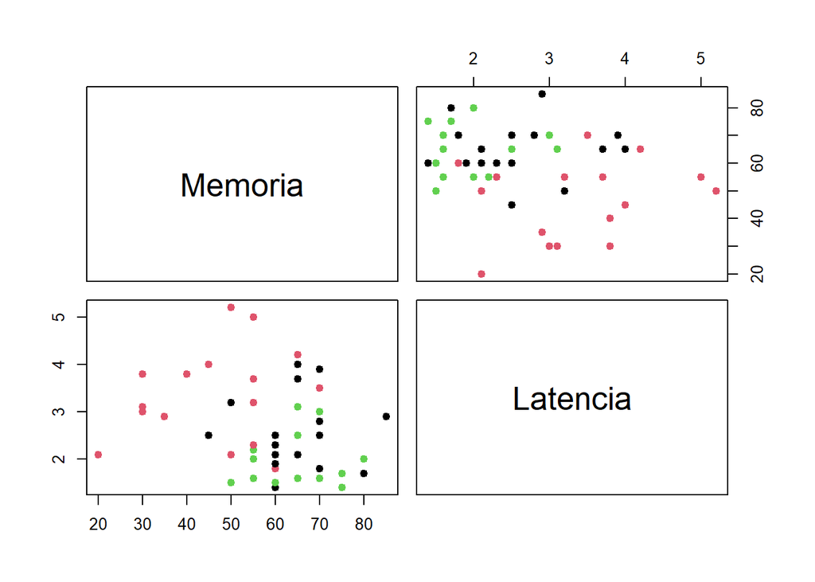

```r
pairs(dados[,3:4], pch = 19,
      col = dados$Alcool)
```

```r
dplyr::select(dados, 2:4)
```

```
##       Alcool Memoria Latencia
## 1  4 Canecas      20      2.1
## 2  4 Canecas      50      5.2
## 3  4 Canecas      55      5.0
## 4  4 Canecas      30      3.8
## 5  2 Canecas      85      2.9
## 6  4 Canecas      30      3.0
## 7  4 Canecas      30      3.1
## 8  4 Canecas      65      4.2
## 9  2 Canecas      70      3.9
## 10 4 Canecas      35      2.9
## 11 2 Canecas      80      1.7
## 12 2 Canecas      65      4.0
## 13 4 Canecas      40      3.8
## 14    Nenhum      80      2.0
```

[output cut: 34 more lines]

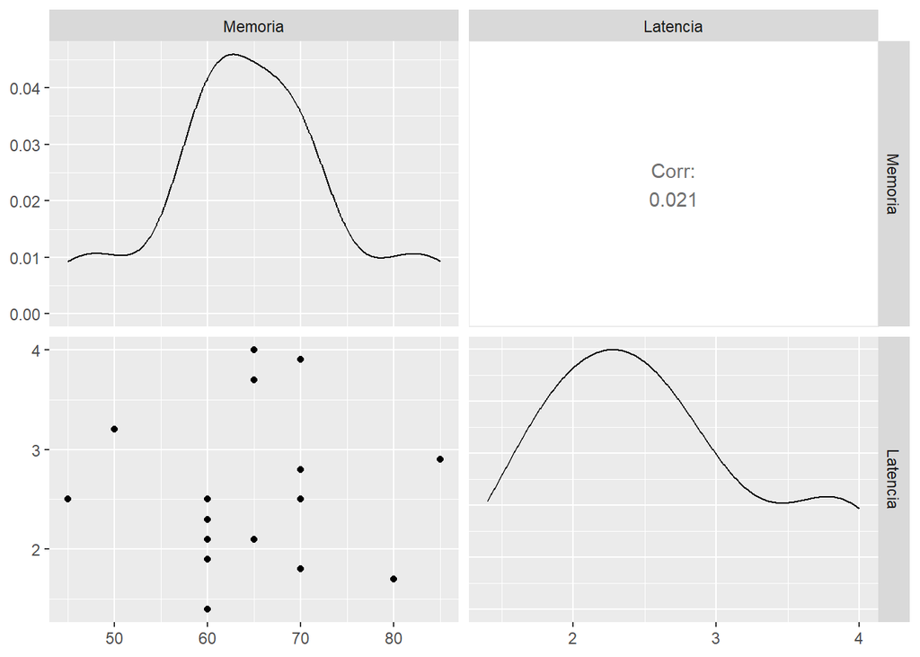

```r
graf <- dados %>% dplyr::select(2:4) %>% group_by(Alcool) %>%
  doo(~ggpairs(.), result = "plots")

graf$plots[which=1]
```

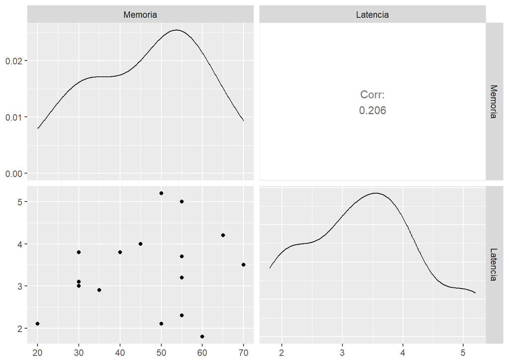

```r
graf$plots[which=2]
```

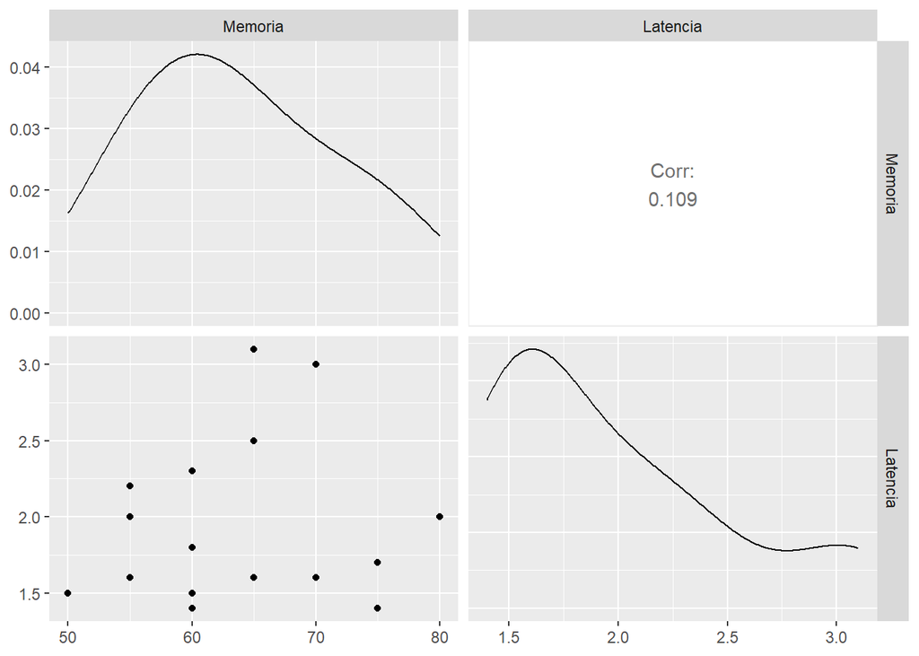

```r
graf$plots[which=3]
```

**SPOILER!!!** Se a MANOVA não é o método mais adequado para análises de dados que não tenham relação de linearidade, qual seria o melhor para análise multivariada? A **análise de discriminante** seria uma opção, nesse caso. Mas seguiremos com a MANOVA.

## 3.8 Passo 8: Modelo de MANOVA

### 3.8.1 Construção do modelo:

```r
modelo <- manova(cbind(Latencia, Memoria) ~ Alcool, data = dados)
modelo
```

```
## Call:
##    manova(cbind(Latencia, Memoria) ~ Alcool, data = dados)
##
## Terms:
##                   Alcool Residuals
## Latencia          15.875    28.604
## Memoria         3332.292  5634.375
## Deg. of Freedom        2        45
##
## Residual standard errors: 0.7972696 11.18965
## Estimated effects may be unbalanced
```

### 3.8.2 Análise dos resultados:

Utilizamos o *teste de `Wilks`* para quando todos os pressupostos, e o *teste de `Pillai`* (mais robusto) para quando pelo menos um dos pressupostos não for atendido.

Seguindo os pressupostos da ANOVA multivariada, temos que:

```r
options(scipen = 999)
summary(modelo, test = "Wilks")
```

```
##           Df  Wilks approx F num Df den Df        Pr(>F)
## Alcool     2 0.4194   11.971      4     88 0.00000008232 ***
## Residuals 45
## ---
## Signif. codes:  0 '***' 0.001 '**' 0.01 '*' 0.05 '.' 0.1 ' ' 1
```

```r
summary(modelo, test = "Pillai")
```

```
##           Df  Pillai approx F num Df den Df      Pr(>F)
## Alcool     2 0.61408   9.9695      4     90 0.000001006 ***
## Residuals 45
## ---
## Signif. codes:  0 '***' 0.001 '**' 0.01 '*' 0.05 '.' 0.1 ' ' 1
```

### 3.8.3 ANOVA univariada:

Seguindo os pressupostos da ANOVA, temos que:

```r
summary.aov(modelo)
```

```
##  Response Latencia :
##             Df Sum Sq Mean Sq F value     Pr(>F)
## Alcool       2 15.875  7.9377  12.488 0.00004853 ***
## Residuals   45 28.604  0.6356
## ---
## Signif. codes:  0 '***' 0.001 '**' 0.01 '*' 0.05 '.' 0.1 ' ' 1
##
##  Response Memoria :
##             Df Sum Sq Mean Sq F value     Pr(>F)
## Alcool       2 3332.3 1666.15  13.307 0.00002883 ***
## Residuals   45 5634.4  125.21
## ---
## Signif. codes:  0 '***' 0.001 '**' 0.01 '*' 0.05 '.' 0.1 ' ' 1
```

## 3.9 Passo 9: *Estimated Marginal Means* (Médias Marginais Estimadas, do Pacote `emmeans`)

Verificamos a comparação entre pares de grupos a fim de ver a significância estatística de suas diferenças (se há diferenças entre quem bebeu nenhuma caneca para quem bebeu duas, e para quem bebeu quatro, assim como de para quem bebeu duas para quem bebeu quatro).

Efetuamos a análise das médias marginais estimadas, corrigidas por `bonferroni`, tanto para `Memoria` quanto para `Latencia`, e na sequência, fazemos um teste de *post-hoc*, com alfa também de 5%.

```r
dados %>% emmeans_test(Memoria ~ Alcool, p.adjust.method = "bonferroni")
```

```
## # A tibble: 3 x 9
##   term   .y.     group1    group2       df statistic         p    p.adj p.adj.~1
## * <chr>  <chr>   <chr>     <chr>     <dbl>     <dbl>     <dbl>    <dbl> <chr>
## 1 Alcool Memoria 2 Canecas 4 Canecas    45     4.58  0.0000365 0.000110 ***
## 2 Alcool Memoria 2 Canecas Nenhum       45     0.237 0.814     1        ns
## 3 Alcool Memoria 4 Canecas Nenhum       45    -4.34  0.0000786 0.000236 ***
## # ... with abbreviated variable name 1: p.adj.signif
```

```r
dados %>% emmeans_test(Latencia ~ Alcool, p.adjust.method = "bonferroni")
```

```
## # A tibble: 3 x 9
##   term   .y.      group1    group2       df statistic          p   p.adj p.adj~1
## * <chr>  <chr>    <chr>     <chr>     <dbl>     <dbl>      <dbl>   <dbl> <chr>
## 1 Alcool Latencia 2 Canecas 4 Canecas    45     -2.75 0.00856    2.57e-2 *
## 2 Alcool Latencia 2 Canecas Nenhum       45      2.24 0.0301     9.03e-2 ns
## 3 Alcool Latencia 4 Canecas Nenhum       45      4.99 0.00000955 2.86e-5 ****
## # ... with abbreviated variable name 1: p.adj.signif
```

Outra opção: *post-hocs*

```r
TukeyHSD(x = aov(Memoria ~ Alcool, data=dados), "Alcool", conf.level = 0.95)
```

```
##   Tukey multiple comparisons of means
##     95% family-wise confidence level
##
## Fit: aov(formula = Memoria ~ Alcool, data = dados)
##
## $Alcool
##                         diff        lwr       upr     p adj
## 4 Canecas-2 Canecas -18.1250 -27.713154 -8.536846 0.0001067
## Nenhum-2 Canecas     -0.9375 -10.525654  8.650654 0.9695381
## Nenhum-4 Canecas     17.1875   7.599346 26.775654 0.0002283
```

```r
TukeyHSD(x = aov(Latencia ~ Alcool, data = dados), 'Alcool', conf.level = 0.95)
```

```
##   Tukey multiple comparisons of means
##     95% family-wise confidence level
##
## Fit: aov(formula = Latencia ~ Alcool, data = dados)
##
## $Alcool
##                         diff         lwr         upr     p adj
## 4 Canecas-2 Canecas  0.77500  0.09183814  1.45816186 0.0228608
## Nenhum-2 Canecas    -0.63125 -1.31441186  0.05191186 0.0753934
## Nenhum-4 Canecas    -1.40625 -2.08941186 -0.72308814 0.0000281
```

## 3.10 Passo 10: Análise descritiva

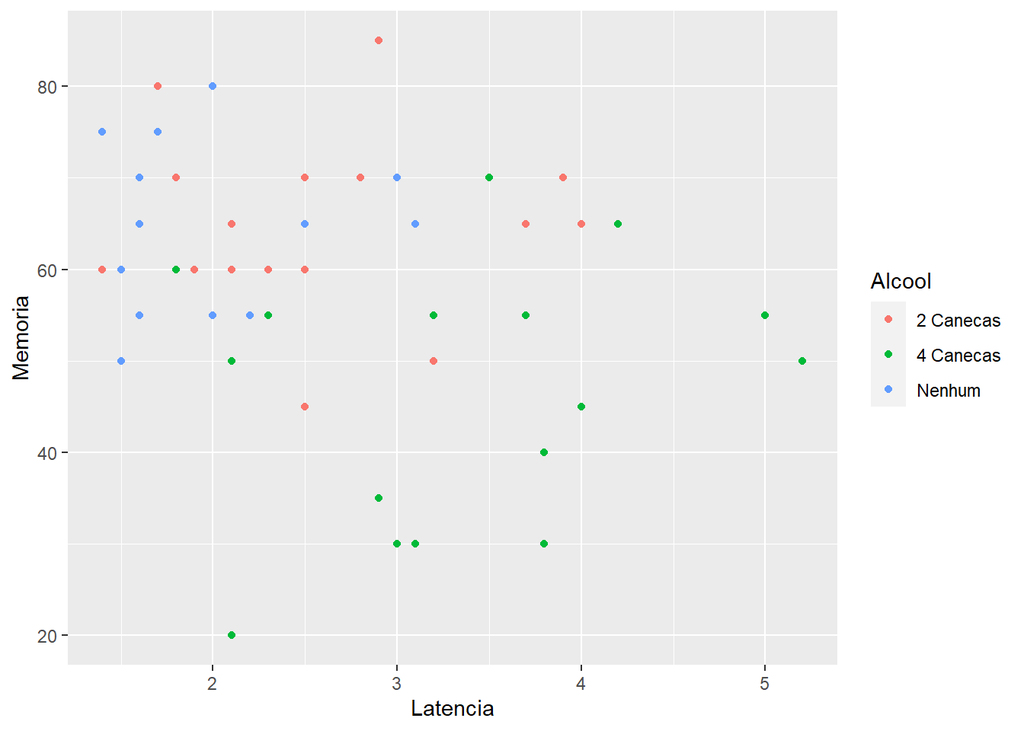

```r
ggplot(dados, aes(x = Latencia, y = Memoria, group = Alcool, color = Alcool)) +
  geom_point()
```

```r
dados %>% group_by(Alcool) %>%
  get_summary_stats(Memoria, Latencia, type = "mean_sd")
```

```
## # A tibble: 6 x 5
##   Alcool    variable     n  mean     sd
##   <fct>     <fct>    <dbl> <dbl>  <dbl>
## 1 2 Canecas Memoria     16 64.7   9.91
## 2 2 Canecas Latencia    16  2.58  0.789
## 3 4 Canecas Memoria     16 46.6  14.3
## 4 4 Canecas Latencia    16  3.36  0.996
## 5 Nenhum    Memoria     16 63.8   8.47
## 6 Nenhum    Latencia    16  1.95  0.54
```

# 4 Resultado